# SC matlab-gorilla comparison

marcobarilari

11/21/2020

## Load and reshape the data

Load the data and add a column for the experiment version, then bind them in one dataframe

```r
SCreframed_gorilla <- read.table('SCreframed_gorilla.tsv',
                                 header = T,
                                 sep = '\t')

SCreframed_matlab <- read.table('SCreframed_matlab.tsv',
                                header = T,
                                sep = '\t')

SCreframed_gorilla$version <- rep('gorilla', nrow(SCreframed_gorilla))
SCreframed_matlab$version <- rep('matlab', nrow(SCreframed_matlab))

SC_all <- rbind(SCreframed_gorilla, SCreframed_matlab)
```

## Look the at the data

Summary of the data

```r
summary(SC_all)
```

```
##           subjID        Response       category        word_code
##  19730317NDGA: 272   small  : 578   Min.   :1.000   am1nu1  :  22
##  19810729MRBR: 272   big    : 566   1st Qu.:3.000   am1nu102:  22
##  19880218PTFR: 272   dark   : 531   Median :6.000   am1nu109:  22
##  19880227DNTM: 272   bright : 525   Mean   :5.294   am1nu114:  22
##  19880701PTCR: 272   near   : 510   3rd Qu.:8.000   am1nu117:  22
##  19910811ARBL: 272   moving : 495   Max.   :9.000   am1nu118:  22
##  (Other)     :4352   (Other):2779                   (Other) :5852
##     meaning         value        version
##  big    : 572   good   :3784   Length:5984
##  dark   : 572   good_op:2200   Class :character
##  small  : 572                  Mode  :character
##  near   : 506
##  bright : 484
##  moving : 484
##  (Other):2794
```

Check that all the participants have the same number of responses per category

```r
table(SC_all$subjID, SC_all$category)
```

```
##
##                 1  3  4  6  7  8  9
##   19730317NDGA 52 48 18 30 44 36 44
##   19810729MRBR 52 48 18 30 44 36 44
##   19880218PTFR 52 48 18 30 44 36 44
##   19880227DNTM 52 48 18 30 44 36 44
##   19880701PTCR 52 48 18 30 44 36 44
##   19910811ARBL 52 48 18 30 44 36 44
##   19930318ANMS 52 48 18 30 44 36 44
##   19930322ATBA 52 48 18 30 44 36 44
##   19961014GOPA 52 48 18 30 44 36 44
##   19661130____ 52 48 18 30 44 36 44
##   19670526ILPN 52 48 18 30 44 36 44
##   19780909____ 52 48 18 30 44 36 44
##   19810809____ 52 48 18 30 44 36 44
##   19830606MRZN 52 48 18 30 44 36 44
##   19851030____ 52 48 18 30 44 36 44
##   19891130____ 52 48 18 30 44 36 44
##   19900126____ 52 48 18 30 44 36 44
##   19901209MRLC 52 48 18 30 44 36 44
##   19920215____ 52 48 18 30 44 36 44
##   19920717____ 52 48 18 30 44 36 44
##   19930320____ 52 48 18 30 44 36 44
##   19940921BRFL 52 48 18 30 44 36 44
```

List the subjects in the Gorilla version

```r
levels(SCreframed_gorilla$subjID)
```

```
## [1] "19730317NDGA" "19810729MRBR" "19880218PTFR" "19880227DNTM" "19880701PTCR"
## [6] "19910811ARBL" "19930318ANMS" "19930322ATBA" "19961014GOPA"
```

List the subjects in the Matlab version

```r
levels(SCreframed_matlab$subjID)
```

```
##  [1] "19661130____" "19670526ILPN" "19780909____" "19810809____" "19830606MRZN"
##  [6] "19851030____" "19891130____" "19900126____" "19901209MRLC" "19920215____"
## [11] "19920717____" "19930320____" "19940921BRFL"
```

## Comparison between the experiment versions

### Over all accuracy

Compute the "raw" accuracy

```r
SC_all$raw_accuracy <- as.integer(SC_all$Response == SC_all$meaning)

SCreframed_gorilla$raw_accuracy <- as.integer(SCreframed_gorilla$Response == SCreframed_gorilla$meaning)
SCreframed_matlab$raw_accuracy <- as.integer(SCreframed_matlab$Response == SCreframed_matlab$meaning)


SC_all %>%
  group_by(version) %>%
  summarize(raw_accuracy = mean(raw_accuracy),
            .groups = 'keep')
```

```
## # A tibble: 2 x 2
## # Groups:   version [2]
##   version raw_accuracy
##   <chr>          <dbl>
## 1 gorilla        0.596
## 2 matlab         0.544
```

Compute the accuracy given that some word in specific native language groups can "sound" with the opposite meaning

from Tzeng et al 2017 Cognitive Science:

### 5.2. Systematic versus “correct” sound-to-meaning mappings

> Of the 80 foreign sound symbolic words, 35 were reverse mappings such that listeners, as a group, reliably mapped them to the opposite of the words’ meanings. That listeners consistently mapped the words to the “wrong” meaning within the dimension for a significant proportion of our items which raises the question of what the functional significance of such sound-to-meaning mappings might be. Indeed, there appears to be some probability that overreliance on sound-to-meaning cues could lead listeners to an incorrect interpretation of specific word meaning (e.g., big vs. small). It may be that the functional utility of sound symbolic cues to meaning is to help constrain the meaning to a particular dimension but does not necessarily determine the specific meaning within this dimension or semantic domain.

Therefor, from our prestudy, we determined wihich stimuli were mapped systematically to the opposite meaning in an indipented sample of native italian speakers. Below we re-compute the accuracy for those stimuli (if the response does not match the meaning we code it as a correct reposnse and vice versa)

```r
SC_all$native_accuracy <- ifelse(SC_all$value == 'good_op',
                                 abs(SC_all$raw_accuracy - 1),
                                 SC_all$raw_accuracy + 0)

SCreframed_gorilla$native_accuracy <- ifelse(SCreframed_gorilla$value == 'good_op',
                                             abs(SCreframed_gorilla$raw_accuracy - 1),
                                             SCreframed_gorilla$raw_accuracy + 0)
SCreframed_matlab$native_accuracy <- ifelse(SCreframed_matlab$value == 'good_op',
                                            abs(SCreframed_matlab$raw_accuracy - 1),
                                            SCreframed_matlab$raw_accuracy + 0)

SC_all %>%
  group_by(version) %>%
  summarize(native_acc = mean(native_accuracy),
            .groups = 'keep')
```

```
## # A tibble: 2 x 2
## # Groups:   version [2]
##   version native_acc
##   <chr>        <dbl>
## 1 gorilla      0.680
## 2 matlab       0.604
```

Display them together

```r
SC_all %>%
  group_by(version) %>%
  summarize(raw_acc = mean(raw_accuracy),
            native_acc = mean(native_accuracy),
            .groups = 'keep')
```

```
## # A tibble: 2 x 3
## # Groups:   version [2]
##   version raw_acc native_acc
##   <chr>     <dbl>      <dbl>
## 1 gorilla   0.596      0.680
## 2 matlab    0.544      0.604
```

### Category accuracy per experiment version

as a reminder:

- categroy 1: size
- categroy 3: brightness
- categroy 4: loudness
- categroy 6: velocity
- categroy 7: movement
- categroy 8: space
- categroy 9: distance

```r
category_acc <- SC_all %>%
  group_by(category, version) %>%
  summarize(raw_acc = mean(raw_accuracy), native_acc = mean(native_accuracy),
            .groups = 'keep')

print(category_acc)
```

```
## # A tibble: 14 x 4
## # Groups:   category, version [14]
##    category version raw_acc native_acc
##       <int> <chr>     <dbl>      <dbl>
##  1        1 gorilla   0.690      0.726
##  2        1 matlab    0.611      0.654
##  3        3 gorilla   0.623      0.720
##  4        3 matlab    0.551      0.615
##  5        4 gorilla   0.531      0.469
##  6        4 matlab    0.474      0.483
##  7        6 gorilla   0.622      0.685
##  8        6 matlab    0.569      0.603
##  9        7 gorilla   0.520      0.639
## 10        7 matlab    0.523      0.580
## 11        8 gorilla   0.559      0.639
## 12        8 matlab    0.509      0.577
## 13        9 gorilla   0.573      0.737
## 14        9 matlab    0.516      0.626
```

Let's reshape the table so that is more readable

```r
reshape2::dcast(melt(category_acc, id = c("category", "version")), category ~ version + variable, value.var = "value", drop = FALSE)
```

```
##   category gorilla_raw_acc gorilla_native_acc matlab_raw_acc matlab_native_acc
## 1        1       0.6901709          0.7264957      0.6109467         0.6538462
## 2        3       0.6226852          0.7199074      0.5512821         0.6153846
## 3        4       0.5308642          0.4691358      0.4743590         0.4829060
## 4        6       0.6222222          0.6851852      0.5692308         0.6025641
## 5        7       0.5202020          0.6388889      0.5227273         0.5804196
## 6        8       0.5586420          0.6388889      0.5085470         0.5769231
## 7        9       0.5732323          0.7373737      0.5157343         0.6258741
```

Plot the accuracies per category and experiment version

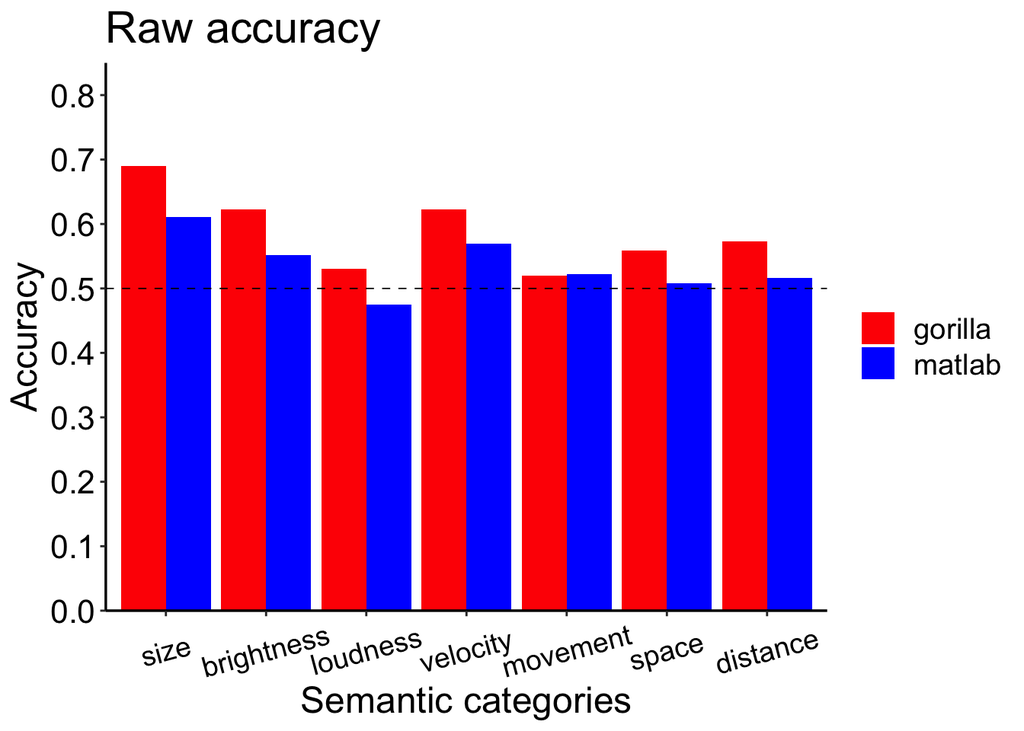

```r
category_acc_tidy <-  melt(category_acc,
                           measure.vars = c('raw_acc', 'native_acc'),
                           variable.name = 'accuracy_id',
                           value.name = 'accuracy')

ggplot(data = subset(category_acc_tidy, accuracy_id == "raw_acc"),
       aes(x = as.factor(category), y = accuracy, fill = version)) +
  geom_bar(stat="identity", position=position_dodge()) +
  theme_classic() +
  scale_fill_manual(values=c('red','blue'), labels=c('gorilla', 'matlab')) +
  scale_y_continuous(limits=c(0, 0.85), breaks=seq(0, 0.85, 0.1), expand = c(0,0)) +
  scale_x_discrete(limits=c("1", "3", "4", "6", "7", "8", "9"),
                   labels = c("size", "brightness", "loudness", "velocity", "movement", "space", "distance")) +
  labs(x="Semantic categories", y="Accuracy") +
  ggtitle("Raw accuracy") +
  theme(
    text=element_text(size=18),
    axis.line = element_line(size = 0.6),
    axis.text.x = element_text(size=14,colour="black",
                               angle = 15,
                               vjust = .5,
                               hjust = 0.5),
    axis.text.y = element_text(size=16, colour='black'),
    legend.title=element_blank())+
  geom_hline(yintercept=c(0.5), linetype="dashed", colour="black", size=0.3)
```

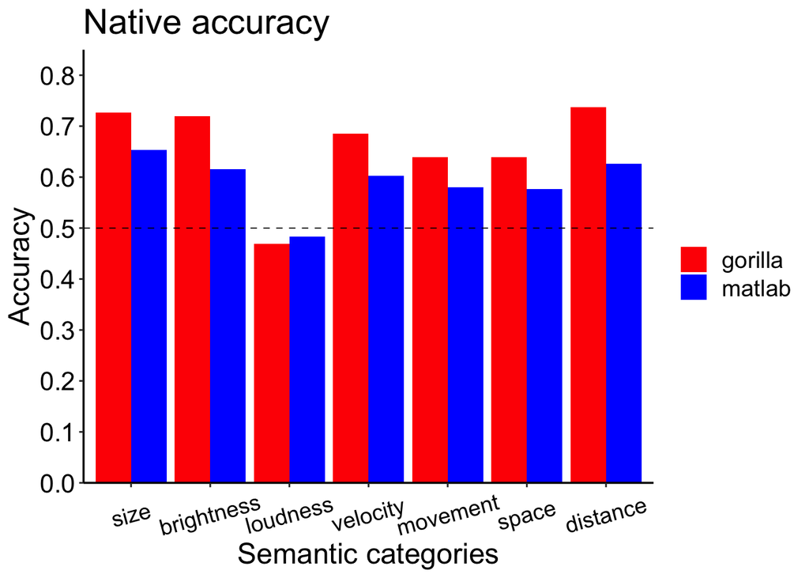

```r
ggplot(data = subset(category_acc_tidy, accuracy_id == "native_acc"),
       aes(x = as.factor(category), y = accuracy, fill = version)) +
  geom_bar(stat="identity", position=position_dodge()) +
  theme_classic() +
  scale_fill_manual(values=c('red','blue'), labels=c('gorilla', 'matlab')) +
  scale_y_continuous(limits=c(0, 0.85), breaks=seq(0, 0.85, 0.1), expand = c(0,0)) +
  scale_x_discrete(limits=c("1", "3", "4", "6", "7", "8", "9"),
                   labels = c("size", "brightness", "loudness", "velocity", "movement", "space", "distance")) +
  labs(x="Semantic categories", y="Accuracy") +
  ggtitle("Native accuracy") +
  theme(
    text=element_text(size=18),
    axis.line = element_line(size = 0.6),
    axis.text.x = element_text(size=14,colour="black",
                               angle = 15,
                               vjust = .5,
                               hjust = 0.5),
    axis.text.y = element_text(size=16, colour='black'),
    legend.title=element_blank())+
  geom_hline(yintercept=c(0.5), linetype="dashed", colour="black", size=0.3)
```